# Practical 1 EDA

Elling Payne

### Loading necessary data and packages

```r
library(tidyverse);
# library(tree);
# library(randomForest);
# library(gbm);
# library(dplyr);
set.seed(112358);
```

```r
# get the data
### As a reminder:
### df; youth_experience_cols, substance_cols, demographic_cols
load("in\\youth_data.Rdata");
```

### Overview of the dataset: What is it about? What information is present?

The data is from the Nation Survey on Drug Use and Health (NSDUH) in 2023. It contains demographic and health information for individuals, information about drug use, and some other behavioral information. Some initial preprocessing has been done by Professor Mendible of Seattle University (2025).

```r
demographic_cols;
```

```
##  [1] "IRSEX"      "NEWRACE2"   "HEALTH2"    "EDUSCHLGO"  "EDUSCHGRD2"
##  [6] "EDUSKPCOM"  "IMOTHER"    "IFATHER"    "INCOME"     "GOVTPROG"
## [11] "POVERTY3"   "PDEN10"     "COUTYP4"
```

```r
substance_cols;
```

```
##  [1] "IRALCFY"     "IRMJFY"      "IRCIGFM"     "IRSMKLSS30N" "IRALCFM"
##  [6] "IRMJFM"      "IRCIGAGE"    "IRSMKLSSTRY" "IRALCAGE"    "IRMJAGE"
## [11] "MRJFLAG"     "ALCFLAG"     "TOBFLAG"     "ALCYDAYS"    "MRJYDAYS"
## [16] "ALCMDAYS"    "MRJMDAYS"    "CIGMDAYS"    "SMKLSMDAYS"
```

```r
youth_experience_cols;
```

```
##  [1] "SCHFELT"  "TCHGJOB"  "AVGGRADE" "STNDSCIG" "STNDSMJ"  "STNDALC"
##  [7] "STNDDNK"  "PARCHKHW" "PARHLPHW" "PRCHORE2" "PRLMTTV2" "PARLMTSN"
## [13] "PRGDJOB2" "PRPROUD2" "ARGUPAR"  "YOFIGHT2" "YOGRPFT2" "YOHGUN2"
## [19] "YOSELL2"  "YOSTOLE2" "YOATTAK2" "PRPKCIG2" "PRMJEVR2" "PRMJMO"
## [25] "PRALDLY2" "YFLPKCG2" "YFLTMRJ2" "YFLMJMO"  "YFLADLY2" "FRDPCIG2"
## [31] "FRDMEVR2" "FRDMJMON" "FRDADLY2" "TALKPROB" "PRTALK3"  "PRBSOLV2"
## [37] "PREVIOL2" "PRVDRGO2" "GRPCNSL2" "PREGPGM2" "YTHACT2"  "DRPRVME3"
## [43] "ANYEDUC3" "RLGATTD"  "RLGIMPT"  "RLGDCSN"  "RLGFRND"
```

### Resolving Value Codes

While the data is clean, there are many values that are not very useful for exploration or input to a model. Within the demographic data, EDUSCHLGO, EDUSCHGRD2, and EDUSKPCOM stand out. These are all related to school attendance and year. For EDUSKPCOM, 94, 97, and 98 are similar in that they represent missing data, while 99 represents missing data but for an individual that has some valid reason for not having that data. Therefore it may make sense in a model to either exclude all so the variable can be used as numeric, or consolidated if the variable is to be transformed into a categorical one. All four codes could be consolidated or 99 could be kept separate. This may also be a good idea since individually these codes do not account for much of the data (besides 99). Whether youth are attending school, EDUSCHLGO, also has several codes that mean the answer is not available, with a bit of nuance. These might all be treated as missing data considering how little data they account for. However, code 11 is interesting because the youth has reported that they are enrolled but has missed 30 days of the last month. Should these be treated as enrolled or not enrolled? Given how sensitive decision trees can be, it might be best to leave 11 as a separate category and observe whether the model identifies it as more similar to 1 or 2. Finally, for the youths grade, EDUSCHGRD2, a 98 represents purely missing data while a 99 represents that the data is missing for some good reason, and so might be useful as a data category. However, this code is not comparable as an ordinal value in the same way as the other grade values may be. It might also make sense to consolidate grade into elementary, middle, high, college, and 99.

```r
# Some hardcoded transformations based on trying to maintain legitimate skip codes as a category
transformDemographics <- function(data) {
  rdata <- data.frame(data);

  # change code 11 to 1 to consolidate yes answers (we'll just worry about what
  # the answer was and also include EDUSKPCOM). Consolidate other codes to NaN
  rdata[["EDUSCHLGO"]] <- as.factor(ifelse(rdata[["EDUSCHLGO"]] %in% c(85, 94, 97, 98), NA,
                                    ifelse(rdata[["EDUSCHLGO"]] == 2, "Enrolled in School",
                                           "Not Enrolled in School")));

  # convert EDUSKPCOM to categorical so we can use the 99 responses
  rdata[["EDUSKPCOM"]] <- as.factor(ifelse(rdata[["EDUSKPCOM"]] == 0, "Skipped School",
                                    ifelse(rdata[["EDUSKPCOM"]] <= 30, "Did Not Skip School",
                                           ifelse(rdata[["EDUSKPCOM"]] %in% c(94, 97, 98), NA,
                                                  "Question N/A"))));

  # properly label blank grade answers
  rdata[["EDUSCHGRD2"]] <- as.factor(ifelse(rdata[["EDUSCHGRD2"]] %in% 1:11, rdata[["EDUSCHGRD2"]],
                                     ifelse(rdata[["EDUSCHGRD2"]] == 99, 99, NA)));

  return(rdata);
}
```

```r
# demographics
summary(df[, demographic_cols]);
```

```
##  IRSEX    NEWRACE2 HEALTH2     EDUSCHLGO   EDUSCHGRD2     EDUSKPCOM
##  1:5387   1:4750   1   :2831   1 :9378   5      :1704   Min.   : 0.00
##  2:5174   2:1284   2   :4031   2 : 999   6      :1673   1st Qu.: 0.00
##           3: 368   3   :2771   11:  22   4      :1589   Median : 0.00
##           4:  50   4   : 915   85:  21   7      :1584   Mean   :27.02
##           5: 503   NA's:  13   94:  85   3      :1370   3rd Qu.:98.00
##           6: 795               97:  46   99     : 999   Max.   :99.00
##           7:2811               98:  10   (Other):1642
##  IMOTHER  IFATHER  INCOME   GOVTPROG POVERTY3 PDEN10   COUTYP4
##  1:9612   1:7514   1:1400   1:3122   1:2433   1:4617   1:4897
##  2: 897   2:2974   2:2766   2:7439   2:2299   2:5353   2:4037
##  3:  52   3:  73   3:1482            3:5829   3: 591   3:1627
##                    4:4913
##
##
##
```

```r
summary(as.factor(df[["EDUSKPCOM"]][df[["EDUSKPCOM"]] > 30]));
```

```
##   94   97   98   99
##  115   18  322 2355
```

```r
# this might motivate a transformation  to binary missed or not + the 99 (3 cats)
summary(df[["EDUSKPCOM"]][df[["EDUSKPCOM"]] <= 30]);
```

```
##    Min. 1st Qu.  Median    Mean 3rd Qu.    Max.
##   0.000   0.000   0.000   1.047   1.000  30.000
```

```r
# 98 is missing data, 99 may indicate they are not enrolled in school
unique(df[["EDUSCHGRD2"]]);
```

```
##  [1] 3  6  2  5  99 4  7  8  98 9  1  10
## Levels: 1 < 2 < 3 < 4 < 5 < 6 < 7 < 8 < 9 < 10 < 98 < 99
```

Notes in order of variables:  
- roughly equal proportion of sex  
- Nonhisp (nh) White 1 -> Hispanic 7 -> nh Black 2 -> nh multi 6 -> nh Asian 5 -> nh NatAM NatAK 3 -> nh Native HI/Pac 4  
- Health Very Good 2 -> Excellent 1 -> Good 3 -> Fair/Poor 4 -> NA  
- Most of the youth are currently attending school or are on a break likely to end (1), but some aren’t (2), or there is other uncertainty (other EDUSCHLGO codes)  
- The respondents are mostly evenly split between grades 7-11 (code 3-7), then then a smaller number are in other grades or other status (1: <= 5th, 2-8: 6th-12th, 9:1st yr college, 10:2nd/3rd yr college, 11:4th yr or higher college, 98:no answer, 99: legitimate skip/break)  
- EDUSKPCOM Over half of the students missed no days from skipping, the rest is unintelligible since 97,98,99 not comparable  
- ~8.5% do not have mother in the household  
- ~28% do not have father in the household  
- income: (1: <20,000), (2:20K-49,999), (3:50K-74,999), (4: >= 75K)  
- govtprog (recieving assitance from Supp. Security Income, foodstamps, cash assistance, non-cash assistance) 1:yes, 2:no  
- poverty: (1: < poverty thresh, computed per person), (2: <= 2X thresh), (3: >2X thresh)  
- pden10: (1: census segment in core-based statistical area with > 1mil people), (2: < 1mil), (3: not in CBSA)  
- coutyp4: (1: county is large metro status), (2: small metro status), (3: nonmetro)

### Cleaning Substance Columns

```r
# This is meaningless for all variables due to the codes 91,93, 991, 993, 6, 5
summary(df[, substance_cols]);
```

```
##     IRALCFY          IRMJFY         IRCIGFM       IRSMKLSS30N
##  Min.   :  1.0   Min.   :  1.0   Min.   : 1.00   Min.   : 1.00
##  1st Qu.:991.0   1st Qu.:991.0   1st Qu.:91.00   1st Qu.:91.00
##  Median :991.0   Median :991.0   Median :91.00   Median :91.00
##  Mean   :820.1   Mean   :876.9   Mean   :89.94   Mean   :90.78
##  3rd Qu.:991.0   3rd Qu.:991.0   3rd Qu.:91.00   3rd Qu.:91.00
##  Max.   :993.0   Max.   :993.0   Max.   :93.00   Max.   :93.00
##     IRALCFM          IRMJFM         IRCIGAGE      IRSMKLSSTRY
##  Min.   : 1.00   Min.   : 1.00   Min.   :  1.0   Min.   :  7.0
##  1st Qu.:91.00   1st Qu.:91.00   1st Qu.:991.0   1st Qu.:991.0
##  Median :91.00   Median :91.00   Median :991.0   Median :991.0
##  Mean   :85.21   Mean   :85.49   Mean   :920.1   Mean   :976.1
##  3rd Qu.:91.00   3rd Qu.:91.00   3rd Qu.:991.0   3rd Qu.:991.0
##  Max.   :93.00   Max.   :93.00   Max.   :991.0   Max.   :991.0
##     IRALCAGE        IRMJAGE      MRJFLAG  ALCFLAG  TOBFLAG     ALCYDAYS
##  Min.   :  1.0   Min.   :  4.0   0:8971   0:8157   0:9603   Min.   :1.000
##  1st Qu.:991.0   1st Qu.:991.0   1:1590   1:2404   1: 958   1st Qu.:6.000
##  Median :991.0   Median :991.0                              Median :6.000
##  Mean   :768.5   Mean   :843.9                              Mean   :5.224
##  3rd Qu.:991.0   3rd Qu.:991.0                              3rd Qu.:6.000
##  Max.   :991.0   Max.   :991.0                              Max.   :6.000
##     MRJYDAYS        ALCMDAYS        MRJMDAYS        CIGMDAYS
##  Min.   :1.000   Min.   :1.000   Min.   :1.000   Min.   :1.000
##  1st Qu.:6.000   1st Qu.:5.000   1st Qu.:5.000   1st Qu.:6.000
##  Median :6.000   Median :5.000   Median :5.000   Median :6.000
##  Mean   :5.557   Mean   :4.756   Mean   :4.826   Mean   :5.943
##  3rd Qu.:6.000   3rd Qu.:5.000   3rd Qu.:5.000   3rd Qu.:6.000
##  Max.   :6.000   Max.   :5.000   Max.   :5.000   Max.   :6.000
##    SMKLSMDAYS
##  Min.   :1.000
##  1st Qu.:5.000
##  Median :5.000
##  Mean   :4.992
##  3rd Qu.:5.000
##  Max.   :5.000
```

```r
reconcileFreqCodes <- function(colname, colvec) {
  # Convert codes that represent no usage to 0 so they can be compared as numeric or ordinal
  yrfreq_names <- c("IRALCFY", "IRMJFY", "IRCIGAGE");
  mnthfreq_names <- c("IRCIGFM", "IRSMKLSS30N", "IRALCFM", "IRMJFM");
  ndays_6cats_names <- c("ALCYDAYS", "MRJYDAYS", "CIGMDAYS");
  ndays_5cats_names <- c("ALCMDAYS", "MRJMDAYS", "SMKLSMDAYS");
  if (colname %in% yrfreq_names) {
    return(ifelse((colvec == 991) | (colvec == 993), 0, colvec));
  }
  else if (colname %in% mnthfreq_names) {
    return(ifelse((colvec == 91) | (colvec == 93), 0, colvec));
  }
  else if (colname %in% ndays_5cats_names) {
    return(ifelse(colvec == 5, 0, colvec));
  }
  else if (colname %in% ndays_6cats_names) {
    return(ifelse(colvec == 6, 0, colvec));
  }
  return(colvec);
};
```

```r
clean_df <- data.frame(df);

for (column in names(clean_df)) clean_df[[column]] <- reconcileFreqCodes(column, clean_df[[column]]);
summary(clean_df[, substance_cols]);
```

```
##     IRALCFY            IRMJFY         IRCIGFM          IRSMKLSS30N
##  Min.   :  0.000   Min.   :  0.0   Min.   : 0.00000   Min.   : 0.00000
##  1st Qu.:  0.000   1st Qu.:  0.0   1st Qu.: 0.00000   1st Qu.: 0.00000
##  Median :  0.000   Median :  0.0   Median : 0.00000   Median : 0.00000
##  Mean   :  3.958   Mean   : 11.1   Mean   : 0.07769   Mean   : 0.02263
##  3rd Qu.:  0.000   3rd Qu.:  0.0   3rd Qu.: 0.00000   3rd Qu.: 0.00000
##  Max.   :339.000   Max.   :365.0   Max.   :30.00000   Max.   :30.00000
##     IRALCFM            IRMJFM           IRCIGAGE        IRSMKLSSTRY
##  Min.   : 0.0000   Min.   : 0.0000   Min.   : 0.0000   Min.   :  7.0
##  1st Qu.: 0.0000   1st Qu.: 0.0000   1st Qu.: 0.0000   1st Qu.:991.0
##  Median : 0.0000   Median : 0.0000   Median : 0.0000   Median :991.0
##  Mean   : 0.2155   Mean   : 0.8106   Mean   : 0.9206   Mean   :976.1
##  3rd Qu.: 0.0000   3rd Qu.: 0.0000   3rd Qu.: 0.0000   3rd Qu.:991.0
##  Max.   :30.0000   Max.   :30.0000   Max.   :17.0000   Max.   :991.0
##     IRALCAGE        IRMJAGE      MRJFLAG  ALCFLAG  TOBFLAG     ALCYDAYS
##  Min.   :  1.0   Min.   :  4.0   0:8971   0:8157   0:9603   Min.   :0.0000
##  1st Qu.:991.0   1st Qu.:991.0   1:1590   1:2404   1: 958   1st Qu.:0.0000
##  Median :991.0   Median :991.0                              Median :0.0000
##  Mean   :768.5   Mean   :843.9                              Mean   :0.2832
##  3rd Qu.:991.0   3rd Qu.:991.0                              3rd Qu.:0.0000
##  Max.   :991.0   Max.   :991.0                              Max.   :5.0000
##     MRJYDAYS         ALCMDAYS         MRJMDAYS         CIGMDAYS
##  Min.   :0.0000   Min.   :0.0000   Min.   :0.0000   Min.   :0.00000
##  1st Qu.:0.0000   1st Qu.:0.0000   1st Qu.:0.0000   1st Qu.:0.00000
##  Median :0.0000   Median :0.0000   Median :0.0000   Median :0.00000
##  Mean   :0.3155   Mean   :0.1039   Mean   :0.1824   Mean   :0.02557
##  3rd Qu.:0.0000   3rd Qu.:0.0000   3rd Qu.:0.0000   3rd Qu.:0.00000
##  Max.   :5.0000   Max.   :4.0000   Max.   :4.0000   Max.   :5.00000
##    SMKLSMDAYS
##  Min.   :0.000000
##  1st Qu.:0.000000
##  Median :0.000000
##  Mean   :0.006344
##  3rd Qu.:0.000000
##  Max.   :4.000000
```

```r
clean_df <- transformDemographics(clean_df);
summary(clean_df[, demographic_cols]);
```

[output not shown]

### Youth Experience Data

The youth experience data is generally binary class data, and is already pretty clean. There are no further steps necessay to prepare the data for tree-based models. However, many of the features to exhibit a great deal of class imbalance, which may limit the models ability to learn about underrepresented populations. In general, since substance usage and criminality is uncommon among youth, classes that represent positive attidudes toward drugs or delinquent behavior are underepresented.

```r
summary(df[, youth_experience_cols]);
```

```
##  SCHFELT  TCHGJOB     AVGGRADE    STNDSCIG    STNDSMJ     STNDALC
##  1:7491   1   :7807   1   : 574   1   :1333   1   :2762   1   :2686
##  2:3070   2   :2711   2   :9271   2   :8851   2   :7354   2   :7421
##           NA's:  43   NA's: 716   NA's: 377   NA's: 445   NA's: 454
##  STNDDNK     PARCHKHW    PARHLPHW    PRCHORE2    PRLMTTV2    PARLMTSN
##  1   : 998   1   :8315   1   :8151   1   :9231   1   :3671   1   :5948
##  2   :9013   2   :2169   2   :2321   2   :1295   2   :6822   2   :4354
##  NA's: 550   NA's:  77   NA's:  89   NA's:  35   NA's:  68   NA's: 259
##  PRGDJOB2    PRPROUD2    ARGUPAR     YOFIGHT2    YOGRPFT2    YOHGUN2
##  1   :8709   1   :8488   1   :8359   1   :1720   1   :1069   1   : 531
##  2   :1789   2   :1996   2   :2022   2   :8774   2   :9428   2   :9984
##  NA's:  63   NA's:  77   NA's: 180   NA's:  67   NA's:  64   NA's:  46
##  YOSELL2      YOSTOLE2     YOATTAK2    PRPKCIG2    PRMJEVR2     PRMJMO
##  1   :  130   1   :  427   1   : 590   1   :9822   1   :8540   1   :8837
##  2   :10406   2   :10094   2   :9930   2   : 643   2   :1920   2   :1624
##  NA's:   25   NA's:   40   NA's:  41   NA's:  96   NA's: 101   NA's: 100
##  PRALDLY2    YFLPKCG2    YFLTMRJ2    YFLMJMO     YFLADLY2    FRDPCIG2
##  1   :9530   1   :9660   1   :8166   1   :8188   1   :9349   1   :9510
##  2   : 940   2   : 811   2   :2306   2   :2281   2   :1119   2   : 905
##  NA's:  91   NA's:  90   NA's:  89   NA's:  92   NA's:  93   NA's: 146
##  FRDMEVR2    FRDMJMON    FRDADLY2    TALKPROB    PRTALK3     PRBSOLV2
##  1   :8110   1   :8222   1   :9277   1   : 644   1   :5585   1   :1945
##  2   :2299   2   :2187   2   :1137   2   :9581   2   :4777   2   :8330
##  NA's: 152   NA's: 152   NA's: 147   NA's: 336   NA's: 199   NA's: 286
##  PREVIOL2    PRVDRGO2    GRPCNSL2     PREGPGM2     YTHACT2     DRPRVME3
##  1   : 801   1   : 761   1   :  211   1   :  379   1   :2003   1   :6611
##  2   :9618   2   :9698   2   :10230   2   :10084   2   :8490   2   :3757
##  NA's: 142   NA's: 102   NA's:  120   NA's:   98   NA's:  68   NA's: 193
##  ANYEDUC3    RLGATTD     RLGIMPT     RLGDCSN     RLGFRND
##  1   :6958   1   :2081   1   :6390   1   :5632   1   :2710
##  2   :3436   2   :8192   2   :3850   2   :4632   2   :7529
##  NA's: 167   NA's: 288   NA's: 321   NA's: 297   NA's: 322
```

Notes from codebook:  
- all are binary responses (1 or 2) with some potentially missing

- SCHFELT: how youth felt about attending school past yr, (1:liked), (2:didn’t like)
- TCHGJOB: teacher told youth they did a good job past year, (1: yes), (2: no)
- AVGGRADE: (1: D or lower), (2: C or higher)
- STNDSCIG: (1: most students in child’s grade/class smokes cigs), (2: not most)
- STNDSMJ, STNDALC: same for marijauna, alcohol
- STNDDDNK: standard to get drunk once a week in youths class/grade (1: yes, 2: no)
- PARCHKHW: did parents check homework completion last yr (1: yes/usually), (2:no/not often)
- PARHLPHW: same but did parents help with homework
- PRCHORE2: parents made youth do chores past year (1: often), (2:no/not often)
- PRLMTTV2: parents limited tv time lasst year (1: yes), (2:no/not often)
- PARLMTSN: parents limit time out on school night
- PRGDJOB2: parents told youth they did a good job past year
- PRPROUD2: parents told youth they were proud of their deeds past year
- ARGUPAR: argued with parents past year (1: <= 9 times), (1: >= 10 times)
- YOUGRPFT2: youth fought group vs group past year (1: yes), (2: no)
- YOHGUN2: youth carried handgun past yr (1: yes), (2: no)
- YOSELL2: youth sold illegal drugs past yr (1: yes), (2: no)
- YOSTOLE2: yth stole past yr (1: yes, 2:no)
- YOATTAK2: yth attacked with intent to harm past yr (1: yes, 2: no)
- PRPKCIG2: how yth thinks their parents feel about yth smoking cigs pack/day (1: strong disapprove, 2: somewhat disapprove or neither)
- PRMJEVR2: how yth thinks their parents feel about trying marijuana
- PRMJMO: how yth thinks their parents feel about monthly marijuana use
- PRALDLY2: how yth thinks parents feel about alc 1-2 drinks per day ((1: strong or somewhat disapprove, 2: neither disapprove nor approve)
- YFLPKCG2: how yth feels about peers smokeing cigs pack per day
- YFLTMRJ2: how yth feels about peers trying marijuana
- YFLMJMO: how yth feels about peers using marijuana monthly
- YFLADLY2: how yth feels about peers having 1-2 alc drinks per day
- FRDPCIG2: how yth thinks friends feel about smoking cigs pack a day
- FRDMEVR2: how yth thinks friends feel about trying marijuana
- FRDMJMON: how yth thinks friends feel about using marijuana once a month
- FRDADLY2: how yth thinks friends feels about having 1-2 alc drinks a day
- TALKPROB: does a yth talk with someone (parent, friend, other) about their problems (1: no one, 2: someone)
- PRTALK3: has a yth talked with parent about dangers of alc, tob, mj? (1: yes, 2: no)
- PRBSOLV2: participated in problem solving, communications skills, or self esteem workshop (1: yes, 2: no)
- PREVIOL2: participated in violence prevention program
- PRVDRGO2: participated in extra-curr substance abuse prevention program
- GRPCNSL2: participated in program to help substance abuse
- PREGPGM2: participated in pregnancy/STD prevention program
- YTHACT2: in how many activities does the youth participate? (1: 0 or 1, 2: 2 or more)
- DRPRVME3: yth has seen an alcohol or drug prevention message outside of school (1: yes, 2: no)
- ANYEDUC3: has yth had any drug/alc prevention education in school? (1: yes, 2: no)
- RLGATTD: How many times yth has attended religious service past year (1: 25 or more, 2: less than 25)
- RLGIMPT: Are religious beliefs very important to yth’s life? (1: agree, 2: disagree)
- RLGDCSN: Religious beliefs influence yth’s life decisions (1: agree, 2: disagree)
- RLGFRND: It’s important for friends to share religious beliefs (1:agree, 2: disagree)
- other variables exist in the full set

### Missing Data

```r
cleaner_df <- clean_df %>% na.omit();
table(sapply(cleaner_df, function(x) {return(paste(class(x), collapse=" "));}));
```

```
##
##         factor        numeric ordered factor
##             60             16              3
```

```r
# check sameness of distributions of features

# chi-squared tests for factors and ordered factors (and discrete numeric)
chisq.results <- list();
for (column in names(cleaner_df)) {
  if (!(is.factor(cleaner_df[[column]]) | is.ordered(cleaner_df[[column]]))) next;
  x <- as.factor(cleaner_df[[column]]);
  y <- as.factor(clean_df[[column]]);
  both_levels <- union(levels(x), levels(y));
  x <- factor(x, levels = both_levels);
  y <- factor(y, levels = both_levels);
  test.result <- chisq.test(table(x), table(y));
  chisq.results[[column]] <- c(test.result$p.value);
}
```

[output not shown]

[output cut: 71 more lines]

[output not shown]

```r
csv_path <- "out\\preprocessing\\data\\chisq_goodness_fit_full_vs_clean.csv";
chisq.results <- data.frame(chisq.results) %>%
  pivot_longer(cols=everything(), names_to="variable",
               values_to="p_value") %>%
  mutate(test_type = "chi_squared");


# kolmogorov-smirnov for discrete numeric
kolsmir.results <- list();
for (column in names(cleaner_df)) {
  if (!is.numeric(cleaner_df[[column]])) next;
  test.result <- ks.test(cleaner_df[[column]], clean_df[[column]]);
  kolsmir.results[[column]] <- c(test.result$p.value);
}
csv_path <- "out\\preprocessing\\data\\kolsmir_goodness_fit_full_vs_clean.csv";
kolsmir.results <- data.frame(kolsmir.results) %>%
  pivot_longer(cols=everything(), names_to="variable",
               values_to="p_value") %>%
  mutate(test_type = "kolmogorov_smirnov");

csv_path <- "out\\preprocessing\\data\\goodness_of_fit_full_vs_clean.csv";
full_test.results <- rbind(chisq.results, kolsmir.results);
write.csv(full_test.results, csv_path, row.names=FALSE);
```

```r
for (column in names(cleaner_df)) {
  if (!is.factor(cleaner_df[[column]]) & !is.ordered(cleaner_df[[column]])) next;
  bar_data <- data.frame(
    class = c(names(table(clean_df[[column]])), names(table(cleaner_df[[column]]))),
    freq = c(as.numeric(table(clean_df[[column]])), as.numeric(table(cleaner_df[[column]]))),
    dataset = c(rep("Original", length(table(clean_df[[column]]))),
                rep("NA Removed", length(table(cleaner_df[[column]]))))
    );
  png(paste0("out\\preprocessing\\plots\\", column, "_freq_full_vs_clean.png"));
  plt <- ggplot(data=bar_data, mapping=aes(x=class, y=freq, fill = dataset)) +
          geom_bar(stat="identity", position="dodge") +
          ggtitle(paste0("Comparison of ", column, " distribution after removing NA values")) +
          scale_fill_manual(values=c("skyblue", "coral"));
  print(plt);
  dev.off();
}
```

```r
for (column in names(cleaner_df)) {
  if (!is.numeric(cleaner_df[[column]])) next;
    dens_data <- data.frame(
    value = c(clean_df[[column]], cleaner_df[[column]]),
    dataset = c(rep("Original", length(clean_df[[column]])),
                rep("NA Removed", length(cleaner_df[[column]])))
    );
  png(paste0("out\\preprocessing\\plots\\", column, "_dens_full_vs_clean.png"));
  plt <- ggplot(data = dens_data) +
    geom_histogram(position="dodge", bins=30, mapping=aes(x=value, fill=dataset)) +
    ggtitle(paste0("Density of ", column, ": full vs cleaned dataset")) +
    scale_fill_manual(values=c("skyblue", "coral"));
  print(plt);
  dev.off();
}
```

### Histograms and Frequency Charts: Non-normality and class imbalance

For variables representing age of first use, the histogram of only those who have ever used is included with an annotation describing the number of youth who have never tried the substance.

```r
# check normality, min, max, mean, var, skew of numeric variables. Create Histograms
numeric_vars <- sapply(cleaner_df, is.numeric);
numeric_cols <- names(cleaner_df)[numeric_vars];
agetry_names <- c("IRSMKLSSTRY", "IRALCAGE", "IRMJAGE");
for (var in numeric_cols) {
  # Histogram
  num_never <- 0;
  if (var %in% agetry_names) {
    # only plot histogram for those who have tried, most have not at all
    to_plot <- cleaner_df[[var]][cleaner_df[[var]] < 90];
    num_never <- length(cleaner_df[[var]]) - length(to_plot);
  }
  else {
    to_plot <- cleaner_df[[var]];
  }
  nbins = min(c(30, length(unique(to_plot))));
  #dev.off()  # Save the file
  png(paste0("out/preprocessing/plots/", var, "_histogram.png"));
  plt <- ggplot(mapping=aes(x=to_plot)) +
    geom_histogram(bins=nbins, fill="skyblue") +
    stat_bin(bins=nbins, geom="text", mapping=aes(label=..count..), vjust=-0.5) +
    ggtitle(paste0("Histogram of ", var)) +
    xlab(var) + ylab("Frequency");

  if (num_never > 0) {
    bin_stats <- ggplot(mapping=aes(x=to_plot)) + stat_bin(bins=nbins);
    bin_stats <- ggplot_build(bin_stats)$data[[1]];
    max_bin_cnt <- max(bin_stats$count)
    plt <- plt + annotate(geom="text", x=1, y=2*max_bin_cnt,
                          label=paste0(num_never, " never tried."),
                          hjust=0, vjust=1, color="red", size=5);
  }
  print(plt);
  dev.off();
}
```

None of the numeric variables appear to be of a normal distribution at first glance. Generally, they are all nonnegative variables heavily skewed right. As a result, in order to fit tree models to predict IRMJFY, transformations of IRMJFY should be considered. A log transformation and a square root transformation are considered, with the log transformation resulting in a greater reduction in skew, but not in normality.

```r
library(moments);
# check if log transformation of IRMJFY results in more normality, less skew
irmjfy_skew <- skewness(cleaner_df[["IRMJFY"]]);
log_irmjfy <- log(cleaner_df[["IRMJFY"]] + 0.001); # nudge values so 0 can be included
log_skew <- skewness(log_irmjfy);
print(paste0("Skew before log transformation: ", irmjfy_skew));
```

```
## [1] "Skew before log transformation: 5.070966175382"
```

```r
print(paste0("Skew after log transformation: ", log_skew));
```

```
## [1] "Skew after log transformation: 2.26468531411913"
```

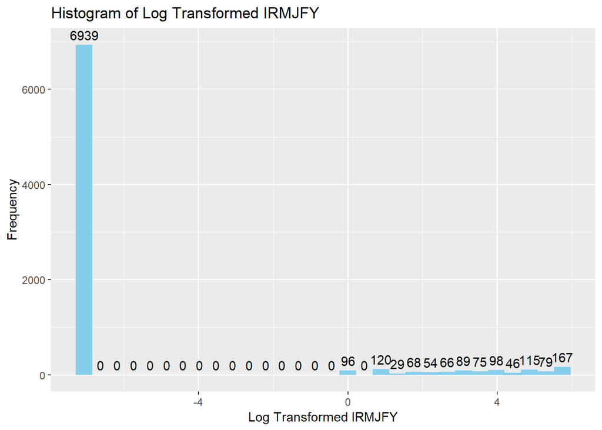

```r
plt <- ggplot(mapping=aes(x=log_irmjfy)) +
    geom_histogram(bins=30, fill="skyblue") +
    stat_bin(bins=30, geom="text", mapping=aes(label=..count..), vjust=-0.5) +
    ggtitle("Histogram of Log Transformed IRMJFY") +
    xlab("Log Transformed IRMJFY") + ylab("Frequency");
print(plt);
```

```r
# check if square root transformation improves things
sqrt_irmjfy <- sqrt(cleaner_df[["IRMJFY"]]);
sqrt_skew <- skewness(sqrt_irmjfy);
print(paste0("Skew before square root transformation: ", irmjfy_skew));
```

```
## [1] "Skew before square root transformation: 5.070966175382"
```

```r
print(paste0("Skew after square root transformation: ", sqrt_skew));
```

```
## [1] "Skew after square root transformation: 3.78870751887199"
```

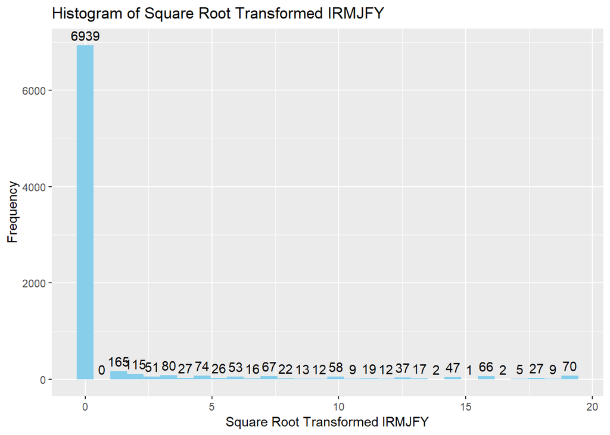

```r
plt <- ggplot(mapping=aes(x=sqrt_irmjfy)) +
    geom_histogram(bins=30, fill="skyblue") +
    stat_bin(bins=30, geom="text", mapping=aes(label=..count..), vjust=-0.5) +
    ggtitle("Histogram of Square Root Transformed IRMJFY") +
    xlab("Square Root Transformed IRMJFY") + ylab("Frequency");
print(plt);
```

```r
# Check class imbalance for factors, mode, and create frequency chart
categorical_vars <- sapply(cleaner_df, is.factor);
categorical_cols <- names(cleaner_df)[categorical_vars];

for (var in categorical_cols) {
  # Create bar plot and save as a file
  png(paste0("out/preprocessing/plots/", var, "_frequency_chart.png"))

  plt <- ggplot(mapping = aes(x = cleaner_df[[var]])) +
    geom_bar(fill = "skyblue", color = "darkgrey") +
    geom_text(stat = "count", aes(label = ..count..), vjust = -0.5, color = "black") +
    labs(title = paste0("Frequency Chart for ", var), x = var, y = "Frequency");
  print(plt);
  dev.off()  # Save the file
}
```

### Testing for potential relationships between features and responses

For comparisons of variables in which one is numeric and the other is a binary factor, a two sample t-test is performed to test whether the means of the numeric variable differ between classes. For Comparison of numeric to a factor with more than two levels, an F-test is performed to test whether any of the class means differ from any other. For comparing factors to other factors, a chis-quared test for goodness of fit is used. Finally, for comparing numeric features to numeric features, no test is performed but the Spearman correlation coefficient is computed for comparison. Spearman was chosen because it may better capture at least some nonlinearity in the relationships, which is expected.

```r
# tests for relationship between potential features and TOBFLAG
feature_names <- names(cleaner_df[,names(cleaner_df) != "TOBFLAG"]);
test_types = character(length(names(cleaner_df))-1);
test_scores = numeric(length(names(cleaner_df))-1);
p_vals = numeric(length(names(cleaner_df))-1);
ind <- 1;
for (feature in feature_names) {
  if (is.factor(cleaner_df[[feature]])) {
    # perform chisquared for target classes vs feature class frequencies
    # Create a contingency table
    cont.table <- table(cleaner_df[["TOBFLAG"]], cleaner_df[[feature]])
    test_types[ind] <- "chi-squared";
    test_result <- chisq.test(cont.table)
    test_scores[ind] <- test_result$statistic
    p_vals[ind] <- test_result$p.value
  }
  else if (is.numeric(cleaner_df[[feature]])) {
    # two sample t-test for means of feature vs target class
    test_types[ind] <- "t-test";
    test_result <- t.test(cleaner_df[[feature]] ~ cleaner_df[["TOBFLAG"]]);
    test_scores[ind] <- test_result$statistic;
    p_vals[ind] <- test_result$p.value;
  }
  else {
    test_types[ind] <- "";
    test_scores[ind] <- NaN;
    p_vals[ind] <- NaN;
    print("Error testing relationship: Feature must be numeric or a factor.");
  }
  ind <- ind + 1;
}
test_df <- data.frame(feature = feature_names, test = test_types,
                      statistic = test_scores, p.value = p_vals);
write.csv(test_df, "out/preprocessing/data/TOBFLAG_vs_features_correlation_metrics.csv",
          row.names = FALSE);
head(test_df);
```

```
##       feature   test  statistic      p.value
## 1     IRALCFY t-test -13.005021 3.460055e-35
## 2      IRMJFY t-test -17.174972 1.666509e-56
## 3     IRCIGFM t-test  -6.461133 1.825009e-10
## 4 IRSMKLSS30N t-test  -3.403455 6.992176e-04
## 5     IRALCFM t-test -10.365665 1.071244e-23
## 6      IRMJFM t-test -14.696064 1.900491e-43
```

```r
# tests for relationship between potential features and ALCYDAYS
feature_names <- names(cleaner_df[,names(cleaner_df) != "ALCYDAYS"]);
test_types = character(length(names(cleaner_df))-1);
test_scores = numeric(length(names(cleaner_df))-1);
p_vals = numeric(length(names(cleaner_df))-1);
ind <- 1;
for (feature in feature_names) {
  if (is.factor(cleaner_df[[feature]])) {
    # perform chisquared for target classes vs feature class frequencies
    # Create a contingency table
    cont.table <- table(cleaner_df[["ALCYDAYS"]], cleaner_df[[feature]])
    test_types[ind] <- "chi-squared";
    test_result <- chisq.test(cont.table)
    test_scores[ind] <- test_result$statistic
    p_vals[ind] <- test_result$p.value
  }
  else if (is.numeric(cleaner_df[[feature]])) {
    # anova F-test (at least one mean differs)
    test_types[ind] <- "F-test";
    test_result <- aov(cleaner_df[[feature]] ~ cleaner_df[["ALCYDAYS"]]);
    test_scores[ind] <- summary(test_result)[[1]][1,4]; # get f-score
    p_vals[ind] <- summary(test_result)[[1]][1,5]; # get p-value
  }
  else {
    test_types[ind] <- "";
    test_scores[ind] <- NaN;
    p_vals[ind] <- NaN;
    print("Error testing relationship: Feature must be numeric or a factor.");
  }
  ind <- ind + 1;
}
```

[output not shown]

[output cut: 8 more lines]

[output not shown]

```r
test_df <- data.frame(feature = feature_names, test = test_types,
                      statistic = test_scores, p.value = p_vals);
write.csv(test_df, "out/preprocessing/data/ALCYDAYS_vs_features_correlation_metrics.csv",
          row.names = FALSE);
head(test_df);
```

```
##       feature   test   statistic       p.value
## 1     IRALCFY F-test 12751.76574  0.000000e+00
## 2      IRMJFY F-test  1720.00713  0.000000e+00
## 3     IRCIGFM F-test   171.65705  8.020951e-39
## 4 IRSMKLSS30N F-test    51.68542  7.098785e-13
## 5     IRALCFM F-test  3510.80131  0.000000e+00
## 6      IRMJFM F-test  1371.15059 2.853594e-277
```

```r
# tests for relationship between potential features and IRMJFY
feature_names <- names(cleaner_df[,names(cleaner_df) != "IRMJFY"]);
test_types = character(length(names(cleaner_df))-1);
test_scores = numeric(length(names(cleaner_df))-1);
p_vals = numeric(length(names(cleaner_df))-1);
ind <- 1;
for (feature in feature_names) {
  if (is.factor(cleaner_df[[feature]]) & nlevels(cleaner_df[[feature]]) == 2) {
    # two sample t-test for means of target vs feature classes
    test_types[ind] <- "t-test";
    test_result <- t.test(cleaner_df[["IRMJFY"]] ~ cleaner_df[[feature]]);
    test_scores[ind] <- test_result$statistic;
    p_vals[ind] <- test_result$p.value;
  }
  else if (is.factor(cleaner_df[[feature]])) {
    # anova F-test for means of target vs feature classes
    test_types[ind] <- "F-test";
    test_result <- aov(cleaner_df[["IRMJFY"]] ~ cleaner_df[[feature]]);
    test_scores[ind] <- summary(test_result)[[1]][1,4]; # get f-score
    p_vals[ind] <- summary(test_result)[[1]][1,5]; # get p-value
  }
  else if (is.numeric(cleaner_df[[feature]])) {
    # do spearman correlations instead of test (spearman since nonlinearity is suspected)
    test_types[ind] <- "Spearman-correlation";
    test_scores[ind] <- cor(cleaner_df[["IRMJFY"]], cleaner_df[[feature]], method="spearman");
    p_vals[ind] <- NaN
  }
  else {
    test_types[ind] <- "";
    test_scores[ind] <- NaN;
    p_vals[ind] <- NaN;
    print("Error testing relationship: Feature must be numeric or a factor.");
  }
  ind <- ind + 1;
}
test_df <- data.frame(feature = feature_names, test = test_types,
                      statistic = test_scores, p.value = p_vals);
write.csv(test_df, "out/preprocessing/data/IRMJFY_vs_features_correlation_metrics.csv",
          row.names = FALSE);
head(test_df);
```

```
##       feature                 test statistic p.value
## 1     IRALCFY Spearman-correlation 0.5294386     NaN
## 2     IRCIGFM Spearman-correlation 0.2552168     NaN
## 3 IRSMKLSS30N Spearman-correlation 0.1138134     NaN
## 4     IRALCFM Spearman-correlation 0.4211290     NaN
## 5      IRMJFM Spearman-correlation 0.7621181     NaN
## 6    IRCIGAGE Spearman-correlation 0.4489952     NaN
```